# Homework1

2025-02-09

by Daniel Diaz-Piedra

Question 1: File Import

```r
employeeData <- read.csv("C:\\Users\\nitro\\Downloads\\Typical_Employee_Survey_Data.csv", header = FALSE)
#feel free to enter your own import statement
```

Question 2: Add Header Row

```r
employeeData <- setNames(employeeData, c("Age", "Gender", "Job Satisfaction", "Job Characteristics", "Years Worked", "Promotion Likelihood", "Agency",
                         "Budgetary Decisions", "Proud Level", "Organization Loyalty", "Workplace Relations"))
```

Question 3: Print out 5 Point Summary and Boxplot for each column

```
##       Age           Gender      Job Satisfaction Job Characteristics
##  Min.   :20.0   Min.   :1.000   Min.   :1.000    Min.   :1.000
##  1st Qu.:33.0   1st Qu.:1.000   1st Qu.:1.000    1st Qu.:2.000
##  Median :38.0   Median :1.000   Median :1.000    Median :5.000
##  Mean   :39.1   Mean   :1.426   Mean   :1.631    Mean   :3.705
##  3rd Qu.:44.0   3rd Qu.:2.000   3rd Qu.:2.000    3rd Qu.:5.000
##  Max.   :64.0   Max.   :2.000   Max.   :4.000    Max.   :5.000
##   Years Worked    Promotion Likelihood     Agency      Budgetary Decisions
##  Min.   : 0.080   Min.   :1.000        Min.   :1.000   Min.   :1.000
##  1st Qu.: 2.000   1st Qu.:2.000        1st Qu.:2.000   1st Qu.:1.000
##  Median : 5.000   Median :4.000        Median :2.000   Median :1.000
##  Mean   : 8.224   Mean   :3.287        Mean   :2.279   Mean   :1.451
##  3rd Qu.:11.000   3rd Qu.:5.000        3rd Qu.:3.000   3rd Qu.:2.000
##  Max.   :52.250   Max.   :5.000        Max.   :4.000   Max.   :2.000
##   Proud Level    Organization Loyalty Workplace Relations
##  Min.   :1.000   Min.   :1.000        Min.   :1.000
##  1st Qu.:1.000   1st Qu.:2.000        1st Qu.:1.000
##  Median :2.000   Median :4.000        Median :2.000
##  Mean   :1.787   Mean   :3.254        Mean   :1.787
##  3rd Qu.:2.000   3rd Qu.:4.000        3rd Qu.:2.000
##  Max.   :4.000   Max.   :5.000        Max.   :4.000
```

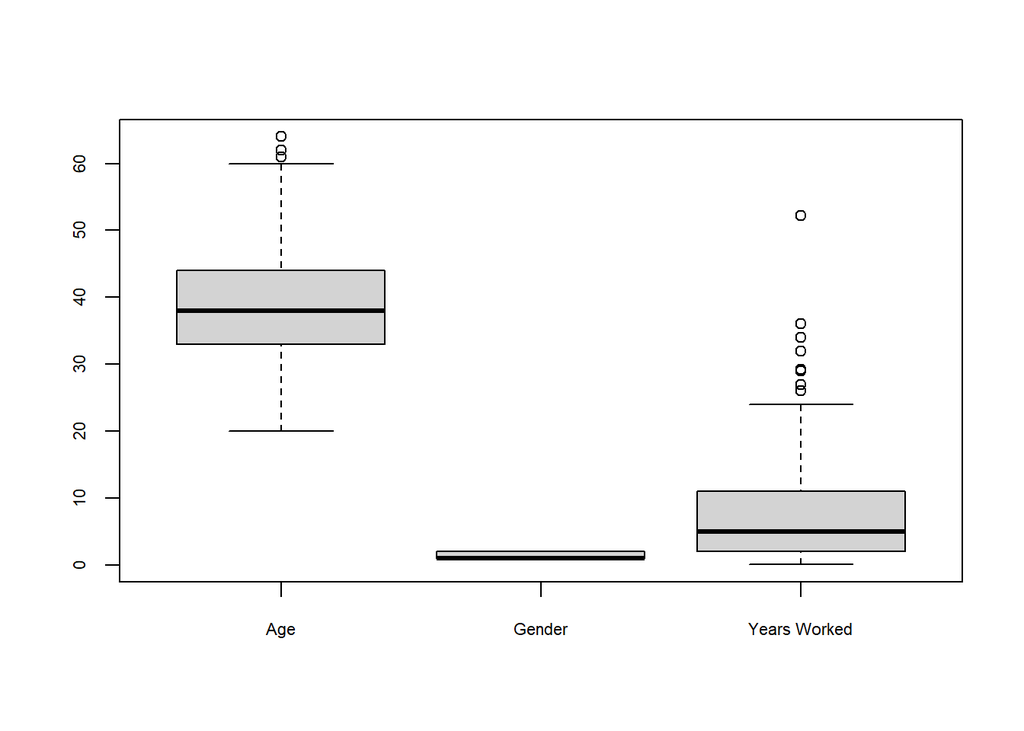

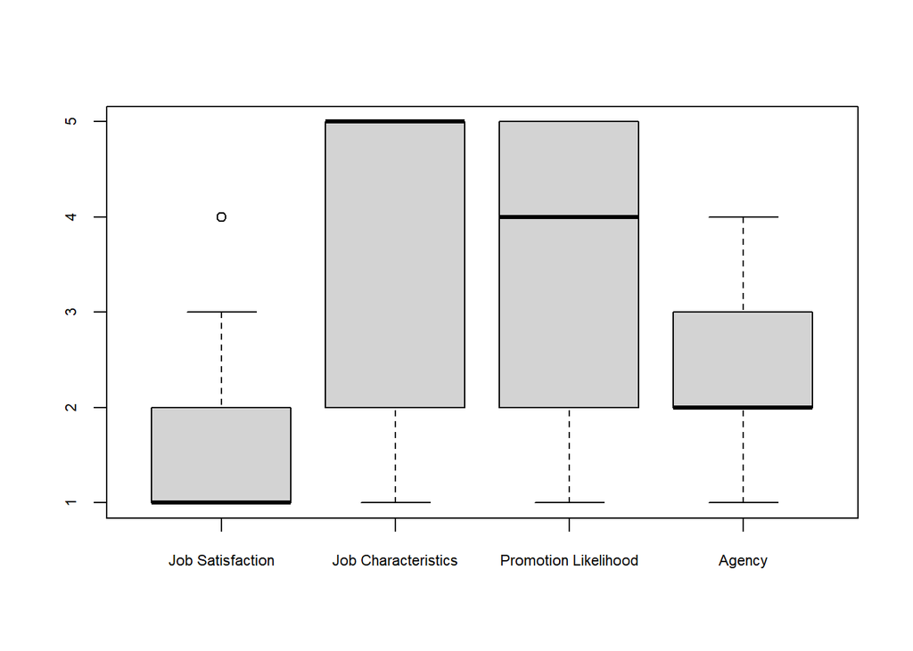

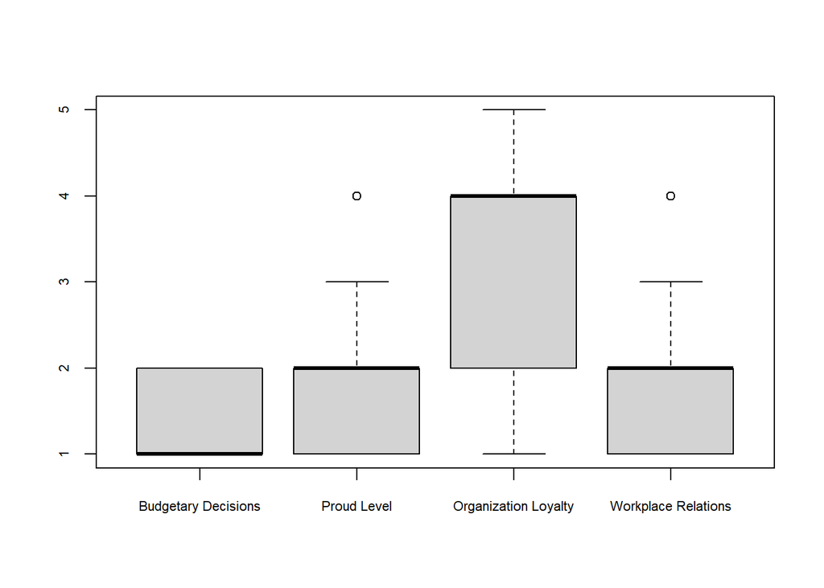

Question 4: Converting Columns to Factors

```
##  Factor w/ 2 levels "Male","Female": 1 1 1 1 1 2 2 1 2 1 ...
```

```
##  Factor w/ 4 levels "Very Satisfied",..: 2 2 1 1 2 2 1 2 1 1 ...
```

```
##  Factor w/ 5 levels "High Income",..: 4 3 1 1 1 1 1 5 5 5 ...
```

```
##  Factor w/ 5 levels "Very Likely",..: 1 5 1 3 3 1 5 2 4 2 ...
```

```
##  Factor w/ 4 levels "Always","Much of the Time",..: 2 2 2 2 2 2 3 1 3 2 ...
```

```
##  Factor w/ 2 levels "Yes","No": 1 1 2 2 1 2 2 2 1 1 ...
```

```
##  Factor w/ 4 levels "Very Proud","Somewhat Proud",..: 2 2 1 1 2 2 2 2 2 1 ...
```

```
##  Factor w/ 5 levels "Very Likely",..: 5 2 5 1 4 4 4 4 2 2 ...
```

```
##  Factor w/ 5 levels "Very Good","Good",..: 2 1 2 1 2 4 1 1 3 2 ...
```

Question 5: Plot the right visual for each column

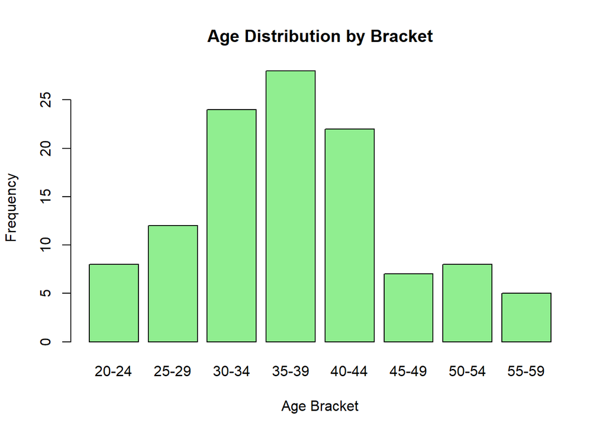

The average age of employees in this organization is 39.1 years. Most employees fall between 28.7 and 49.5 years old. The overall work force is fairly young and mostly around the same age

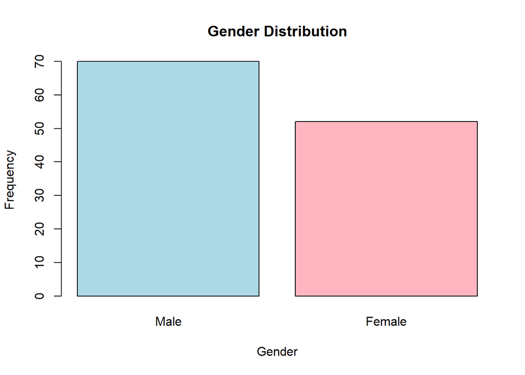

This organization is 57.4% male and 42.6% female. This gender ratio might be skewed too much in favor of men

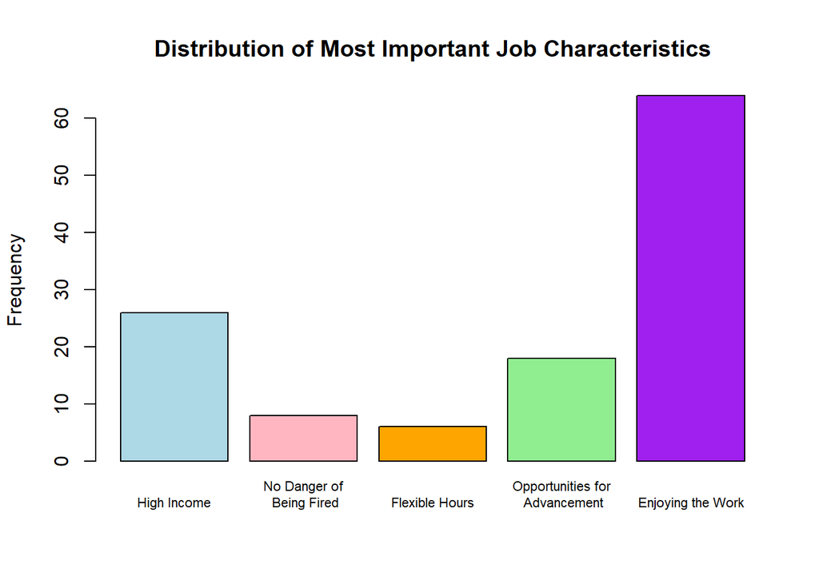

Members of this organization seem to overwhelmingly care about how enjoyable the work is, and don’t seem to care much about the risk of being fired or how flexible their hours are

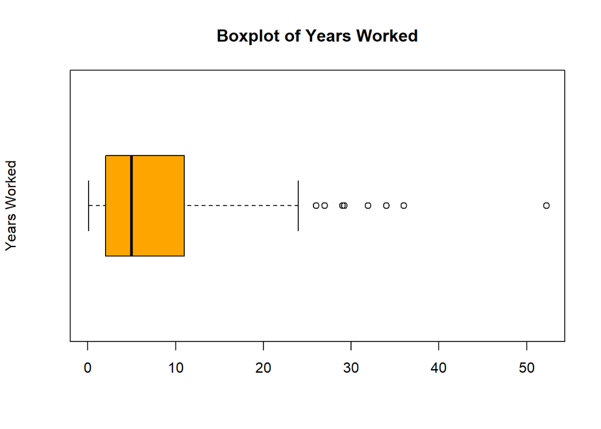

Of all employees, 57 have worked at the company for less than 5 years, 82 have worked for less than 10 years and 40 have worked for over 10 years. Overall the average employee has been at the company for a few years and a pretty significant portion stay at the company

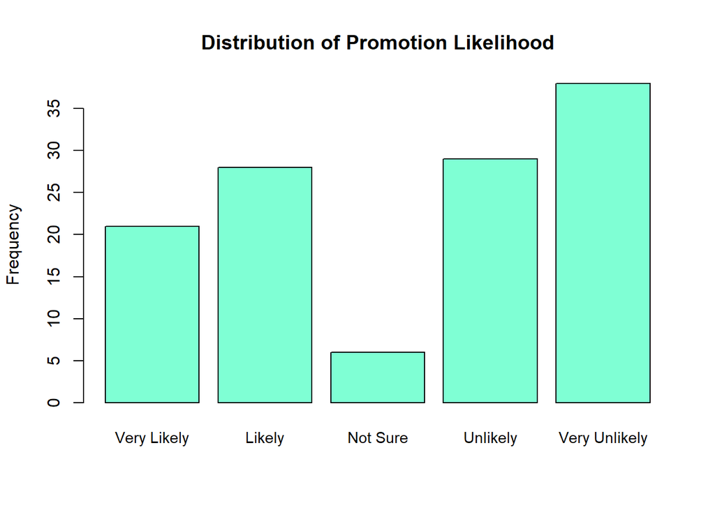

Overwhelmingly employees seem to know if they are to be promoted or not, with the split between either side being fairly even with a slight skew towards unlikely to be promoted

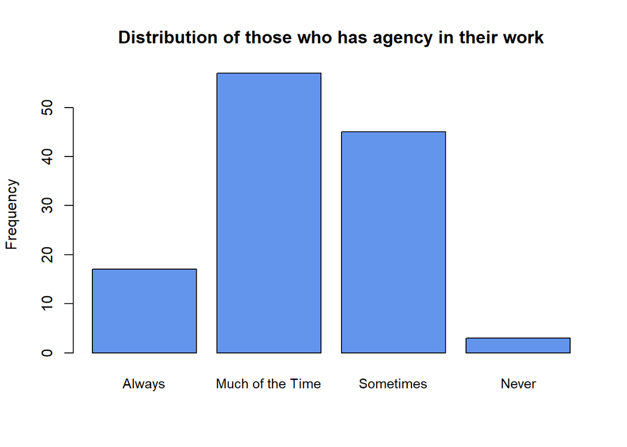

Overwhelmingly employees feel they have agency in their day to day operations and that their decisions directly impact their work, hardly anyone feels disconnected between their daily decisions and work

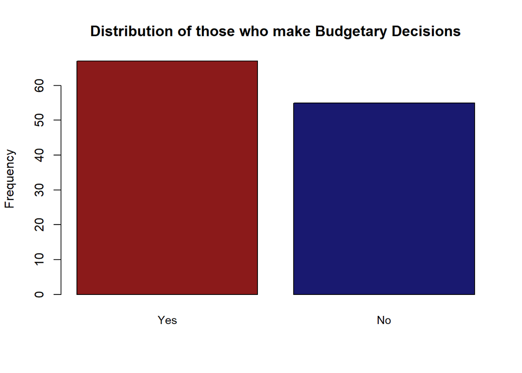

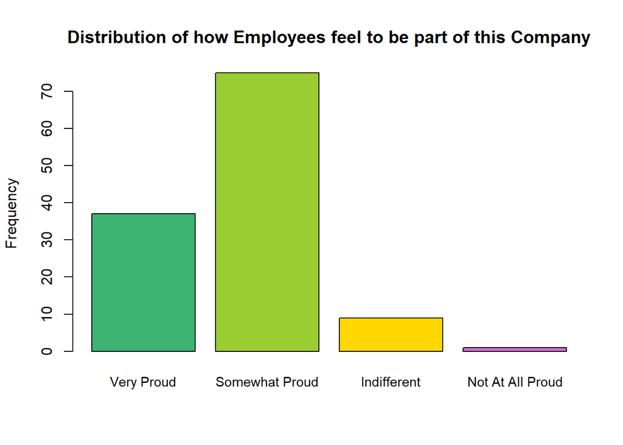

Overwhelmingly Employees are happy to be a part of this organization, the number of employees that are not proud is extremely small

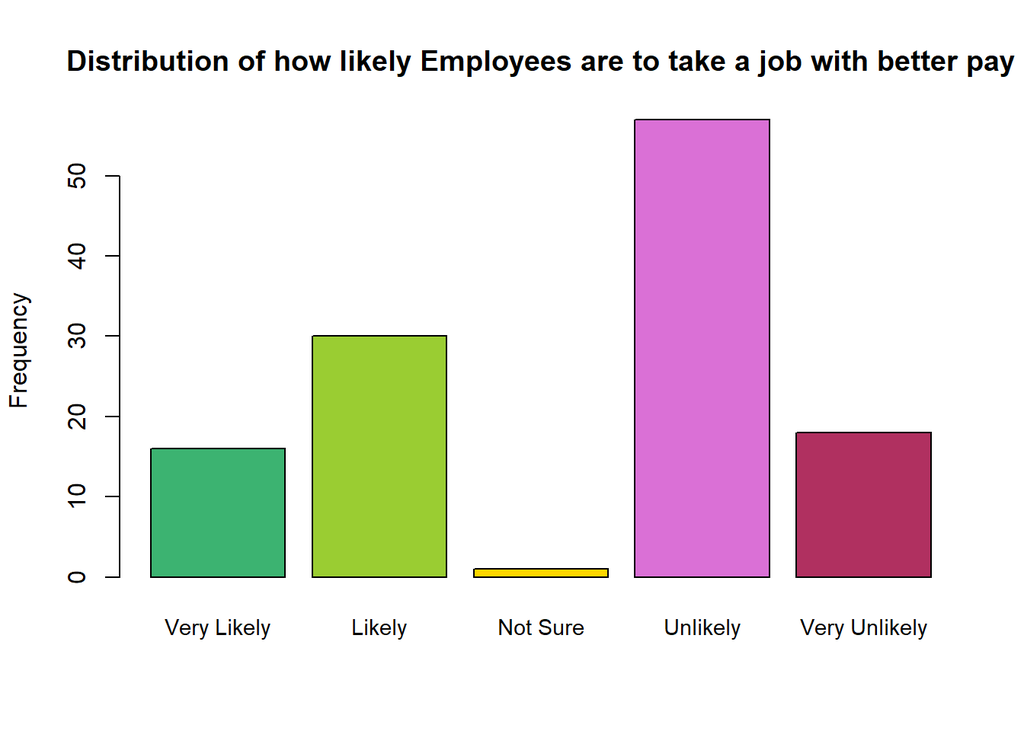

Even though pay was not a massive consideration, and employees are very proud to be part of this organization, 37.7% would likely take a job from another company for better pay

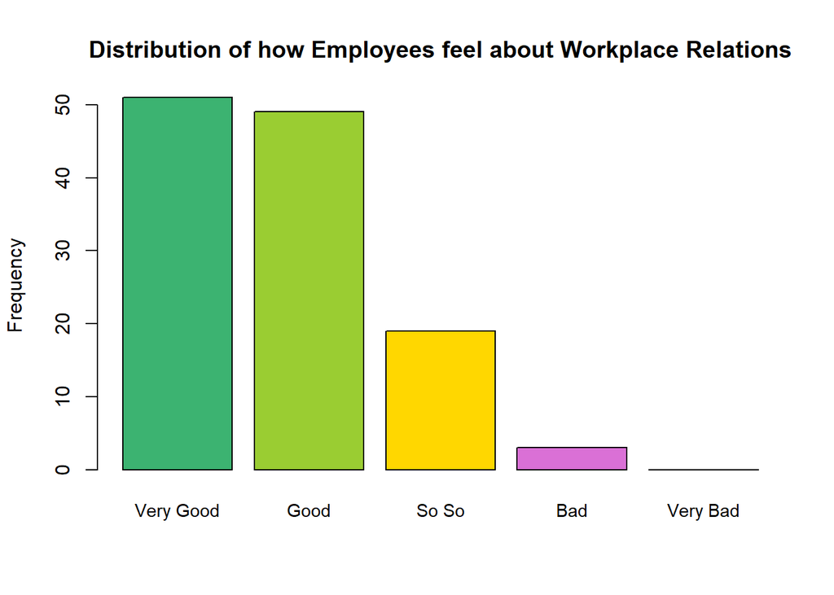

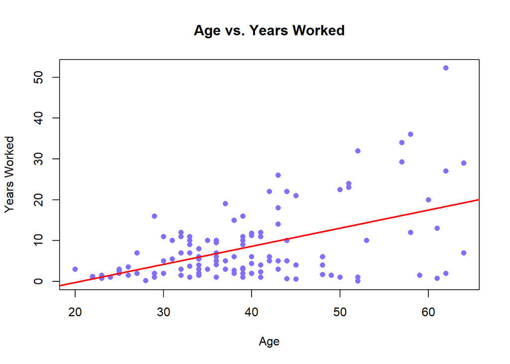

There seems to be a fairly strong correlation between the age of an employee and the amount of years worked at the company. This implies that employees stick around at this company for a long duration of time

[figure not shown]

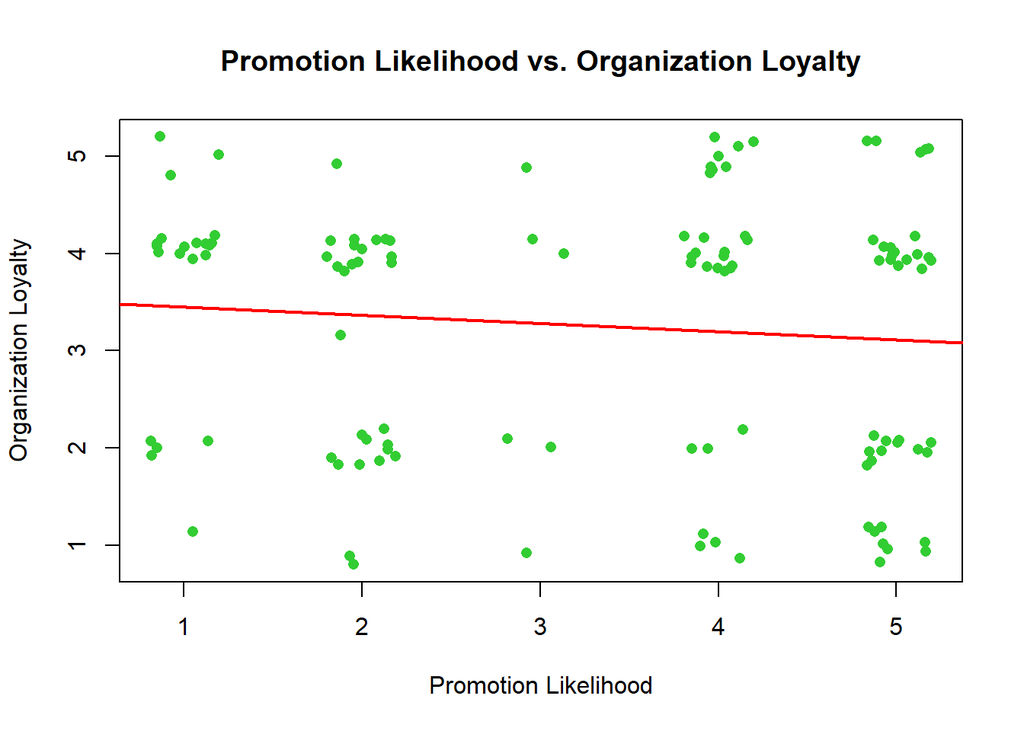

There seems to be almost no correlation between how loyal someone is to the organization and how likely they are to be promoted

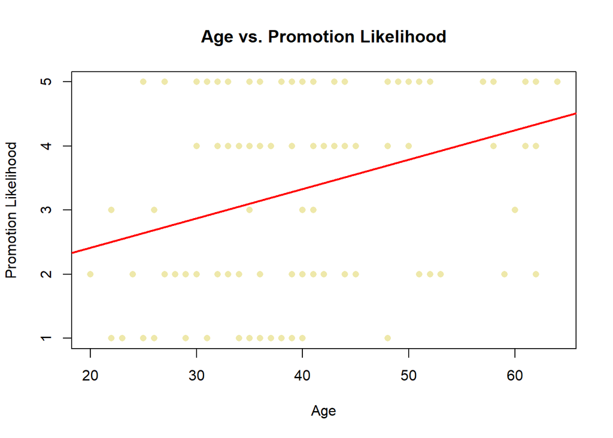